# Grid World Example

Junmo Nam

그리드 월드 환경에서 SARSA와 Q Learning을 적용해보기 위해 만든 예제입니다.

## 환경 설정하기

그리드 문제 환경설정입니다.

### 함수 및 패키지 로딩과 파라미터 설정

먼저 예제에서 사용할 패키지인 dplyr과 ggplot2, devtools를 로딩합니다.

다음으로 파라미터를 설정합니다. params는 학습을 위한 파라미터들을 담고 있는 리스트로, 각각 입실론, 할인율, 학습률을 의미합니다.

마지막으로 학습에 쓸 함수들이 있는 스크립트를 gist에서 불러옵니다.

```r
#load package
sapply(c('dplyr','ggplot2','devtools'),require,character.only = T)
```

```
##    dplyr  ggplot2 devtools
##     TRUE     TRUE     TRUE
```

```r
#claim SARSA parameters
params = list(
  epsilon = 0.1,
  discount = 0.9,
  learning_rate = 0.01
)

#sourcing function
source_gist("https://gist.github.com/JunmoNam/d24bb9f087649df82c83d3b66b857627")
```

### 그리드 설정

그리드 환경은 grid라는 매트릭스로 표현합니다.  
0은 별다른 조건이 없는 칸들이며 -1은 장애물, 1은 도착지입니다.

```r
grid = matrix(0,5,5)
grid[2,3]=-1;grid[2,5]=-1;grid[3,4]=-1;grid[4,2]=-1;
grid[4,4] = 1

grid
```

```
##      [,1] [,2] [,3] [,4] [,5]
## [1,]    0    0    0    0    0
## [2,]    0    0   -1    0   -1
## [3,]    0    0    0   -1    0
## [4,]    0   -1    0    1    0
## [5,]    0    0    0    0    0
```

## SARSA

### SARSA 학습 진행

불러온 코드 중 SARSA_grid라는 함수를 이용하여 학습을 진행합니다. 함수는 그리드 환경, 파라미터, iteration 횟수를 입력값으로 받습니다.

```r
res = SARSA_grid(grid,params,100)
```

*SARSA는 특성상 중간에 갇혀서 학습이 멈춰버릴 수 있으니 결과가 안 나오거나 오래 걸리면 다시 시도하는 걸 추천합니다.

### SARSA 학습 결과 시각화

학습이 완료되었으면 학습된 정책이 실제 그리드에서 어떻게 따라가는지를 시각화합니다.

Plot에서 파란 점은 이동경로를, 초록색은 장애물을 그리고 빨간색은 도착점을 의미합니다.

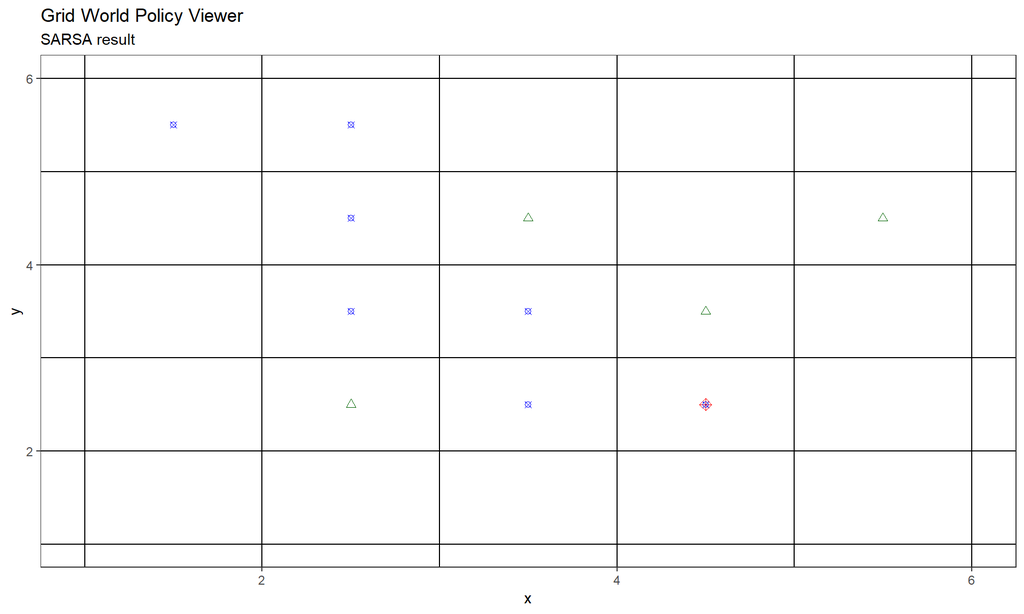

```r
draw_policy(grid,res$qpolicy,res$warning,'SARSA')
```

단, 결과값 객체의 warning이 TRUE일 경우(= 학습이 잘못 진행된 경우) 해당 코드는 작동하지 않습니다.

## Q-Learning

### 큰 Grid와 Q-Learning 학습

Q Learning은 SARSA와 차별화를 위해 좀 더 복잡한 그리드 환경에서 실험해보도록 하겠습니다.

7*9 그리드에 장애물도 보다 많이 추가되었으며, (6,8)이라는 비교적 먼 곳에 도착점이 위치해있습니다.

```r
grid = matrix(0,7,9)
grid[2,3]=-1;grid[2,5]=-1;grid[3,4]=-1;grid[4,2]=-1;grid[4,6:9] = -1;grid[6:7,2] = -1;grid[5,5]=-1
grid[6,8] = 1
```

새로 세팅된 그리드를 QL_grid함수로 학습시킵니다.

```r
res = QL_grid(grid,params,100)
```

### Q-Learning 학습 결과 시각화

SARSA와 마찬가지로 Q-learning으로 학습된 정책을 시각화를 해주면 다음과 같이 나오게 됩니다.

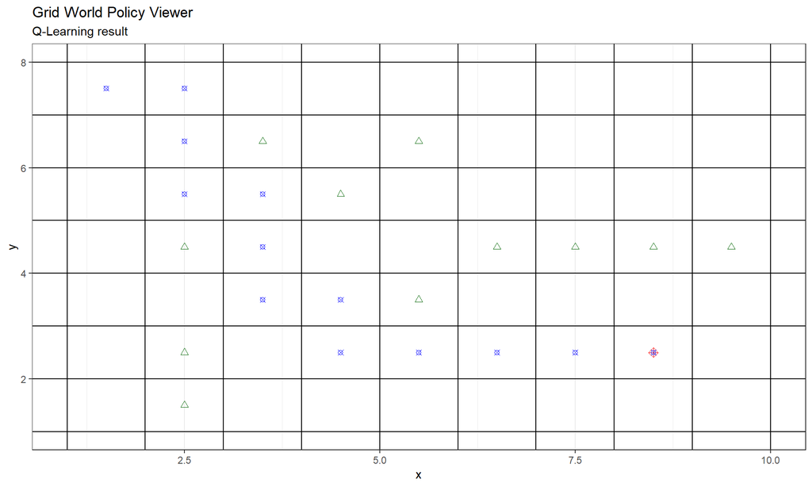

```r
draw_policy(grid,res$qpolicy,res$warning,'Q-Learning')
```

## 소스 파일 이해하기

소스 스크립트는 마크다운 하단 혹은 [GIST](https://gist.github.com/JunmoNam)의 SARSA_QL_solver.R에서 확인할 수 있습니다.

### step 함수

step함수는 주어진 상태(state)와 행동(action)에 따른 다음 상태 s’와 보상(reward)를 결과로 주는 함수입니다. 그리드 월드 환경에 맞는 규칙들로 구성되어 있으며, 에이전트가 그리드 내에서 갈 수 없는 행동을 선택하면 가만히 있도록 설정되있습니다.

```r
step = function(state,action){

  #x and y in state
  x = state$x
  y = state$y

  #define reward and next state by condition
  if(x==nrow(grid) & action == 'down' | y==ncol(grid) & action == 'right' |
     x==1 & action == 'up' | y==1 & action == 'left'){
    # action not allowed, stay
    reward = grid[x,y]
    next_state = state
  }else if(action == 'up'){
    reward = grid[x-1,y]
    next_state = list(x = x-1,y = y)
  }else if(action == 'down'){
    reward = grid[x+1,y]
    next_state = list(x = x+1,y = y)
  }else if(action == 'left'){
    reward = grid[x,y-1]
    next_state = list(x = x,y = y-1)
  }else{
    reward = grid[x,y+1]
    next_state = list(x = x,y = y+1)
  }
  return(list(next_state = next_state,reward = reward))
}
```

### get_action 함수

주어진 상태와 입실론, qtable(=q값들이 저장된 테이블)과 actions(가능한 행동 리스트, 상/하/좌/우)를 입력값으로 받아서 행동을 선별해주는 함수입니다. 입실론-그리디 정책에 기반하며 입실론 값 만큼의 확률로 랜덤행동을 하며, 아닐 경우 주어진 상황 중 최대의 q값을 가지는 행동을 합니다. 만약 최대 q값을 가지는 행동이 여러 개일 경우 1가지를 선택해서 하게 됩니다.

```r
get_action = function(state,epsilon,qtable,actions){
  x = state$x
  y = state$y

  ifelse(sample(0:1,1,prob = c(epsilon,1-epsilon))==1, #epsilon check
         (filter(qtable,x==!!x,y==!!y) %>% #filter by state
            filter(q == max(q)) %>% #get maximum q
            sample_n(1) #sample one if there's multiple max q
         )$action, #do max q action
         sample(actions,1))#random action

}
```

### SARSA_grid 함수

SARSA 알고리즘을 앞서 정의한 환경 및 함수들로 진행하는 코드입니다. 앞서 언급했듯이 SARSA 코드가 빠져나오지 못하고 맴돌 수 있기 때문에 일정 스텝($=(nrow*ncol)^2$)이 넘어가도록 빠져나오지 못하면 학습을 종료하도록 설정되어 있습니다.

```r
SARSA_grid = function(grid,params,n_iter){

  #allow only 4 actions
  actions = c('up','down','left','right')

  #get parameters
  epsilon = params$epsilon
  discount = params$discount
  learning_rate = params$learning_rate

  #claim q table
  qtable = expand.grid(x = 1:nrow(grid),y = 1:ncol(grid),action = actions,q = 0) %>%
    mutate(action = as.character(action))

  #do iteration
  p = progress_estimated(n_iter)

  for(i in 1:n_iter){

    warning = F

    #reset state
    state = list(x = sample(1:nrow(grid),1),y = sample(1:ncol(grid),1))

    #select action
    action = get_action(state,epsilon,qtable,actions)
    n_step = 0

    repeat{

      #define next state
      time_step = step(state,action)
      next_state = time_step$next_state
      reward = time_step$reward
      done = (reward ==1)
      next_action = get_action(next_state,epsilon,qtable,actions)

      #update q by SARSA : Bellman update
      q = filter(qtable,x==state$x,y==state$y,action==!!action)$q
      q2 = filter(qtable,x==next_state$x,y==next_state$y,action==!!next_action)$q
      new_q = q + learning_rate*(reward + discount*q2-q)

      #get new q values to table
      qtable = qtable %>%
        mutate(q = replace(q,x==state$x &
                             y==state$y &
                             action == !!action,new_q))

      #update states
      state = next_state
      action = next_action

      #step count
      n_step = n_step+1


      if(done){
        break
      }else if(n_step>(dim(grid) %>% prod)^2){
        warning = T
        break
      }

    }#end repeat
    p$tick()$print()

    if(warning){
    cat('\n number of step is more than (nrow(grid)*ncol(grid))^2 : consider SARSA caught in infinite loop \n break \n')
      break
    }

  }
  qpolicy = qtable %>% group_by(x,y) %>% filter(q == max(q)) %>% arrange(x,y)

  return(list(warning = warning, qpolicy = qpolicy,qtable = qtable))
}
```

### QL_grid 함수

Q-Learning을 진행하는 코드입니다. SARSA와 다른 점은 q의 업데이트 공식과 다음 행동을 저장해줄 필요가 없기 때문에 repeat문의 처음에만 정의한다는 것입니다.

```r
QL_grid = function(grid,params,n_iter){

  #allow only 4 actions
  actions = c('up','down','left','right')

  #get parameters
  epsilon = params$epsilon
  discount = params$discount
  learning_rate = params$learning_rate

  #claim q table
  qtable = expand.grid(x = 1:nrow(grid),y = 1:ncol(grid),action = actions,q = 0) %>%
    mutate(action = as.character(action))

  #do iteration
  p = progress_estimated(n_iter)

  for(i in 1:n_iter){

    warning = F

    #reset state
    state = list(x = sample(1:nrow(grid),1),y = sample(1:ncol(grid),1))

    n_step = 0

    repeat{

      #select action
      action = get_action(state,epsilon,qtable,actions)

      #define next state
      time_step = step(state,action)
      next_state = time_step$next_state
      reward = time_step$reward
      done = (reward ==1)

      #update q by SARS : Bellman update
      q = filter(qtable,x==state$x,y==state$y,action==!!action)$q
      q2 = reward + discount*(filter(qtable,x==next_state$x,y==next_state$y) %>% filter(q==max(q)) %>% sample_n(1))$q
      new_q = q + learning_rate*(q2-q)

      #get new q values to table
      qtable = qtable %>%
        mutate(q = replace(q,x==state$x &
                             y==state$y &
                             action == !!action,new_q))

      #update states
      state = next_state


      #step count
      n_step = n_step+1


      if(done){
        break
      }else if(n_step>(dim(grid) %>% prod)^2){
        warning = T
        break
      }

    }#end repeat
    p$tick()$print()

    if(warning){
      cat('\n number of step is more than (nrow(grid)*ncol(grid))^2 : consider Q learning caught in inefficient loop \n break \n')
      break
    }

  }
  qpolicy = qtable %>% group_by(x,y) %>% filter(q == max(q)) %>% arrange(x,y)

  return(list(warning = warning, qpolicy = qpolicy,qtable = qtable))
}
```

### draw_policy 함수

ggplot 기반으로 학습 결과로 나온 최적 정책을 그려주는 함수입니다. 나온 정책을 따라간 후 그 결과를 plotting해주기 때문에 다소 시간이 소요될 수 있으며, 잘못 학습된 정책이면 plot이 그려지지 않습니다.

```r
#drawing
draw_policy = function(grid,qpolicy,warning,method){

  #mapping destination and obstacle
  obstacle = which(grid==-1,arr.ind = T)
  destination = which(grid==1,arr.ind = T)

  if(warning){
    stop('Your policy has some problem : check object "warning" and policy before draw policy')
  }

  #check start point and action
  state = list(x=1,y=1)
  action = (qpolicy %>% filter(x==state$x,y==state$y))$action

  if(action == 'up' | action == 'left'){
    stop('Your policy ask agent to do illegal movement : stop')
  }

  #make record dataframe
  record = data.frame(x=state$x,y=state$y)

  #do recording by given q policy
  repeat{

    #update state
    res = step(state,action)
    state = res$next_state
    done = (res$reward==1)

    #done
    if(!done){

      #check
      if(res$reward == -1){
        stop('Your policy ask agent to go wall : stop')
      }

      #choose action by existing policy
      action = (qpolicy %>% filter(x==state$x,y==state$y))$action

      #check
      if(state$x==nrow(grid) & action == 'down' | state$y==ncol(grid) & action == 'right' |
         state$x==1 & action == 'up' | state$y==1 & action == 'left'){
        stop('Your policy ask agent to do illegal movement : stop')
      }

      #update record
      record = rbind(record,data.frame(x=state$x,y=state$y))

      #chekc policy ask to loop or not
      if(TRUE %in% duplicated(record)){
        stop('Your Policy ask agent to go visted area : This might cause infinite loop. stop')
      }
    }else{

      #update record
      record = rbind(record,data.frame(x=state$x,y=state$y))
      break
    }
  }

  #visualization : make empty grid object
  grid_plot = expand.grid(x=1:(ncol(grid)+1),y=1:(nrow(grid)+1)) %>% ggplot(aes(x,y))+
    geom_point(alpha=0)+
    geom_vline(xintercept = 1:(ncol(grid)+1))+
    geom_hline(yintercept = 1:(nrow(grid)+1))+
    ggtitle('Grid World Policy Viewer',
            subtitle = paste(method,'result'))+
    theme_bw()

  #add obstacle and destination
  for(i in 1:nrow(obstacle)){
    x_add = obstacle[i,2]+0.5
    y_add = (nrow(grid)+1)-obstacle[i,1]+0.5
    grid_plot = grid_plot +
      geom_point(aes(x = !!x_add, y= !!y_add),shape = 2,color = 'dark green',size = 2)
  }

  #add destination
  grid_plot = grid_plot +
    geom_point(aes(x = destination[1,2]+0.5,
                   y= (nrow(grid)+1)-destination[1,1]+0.5),
               shape = 9,color = 'red',size = 2.5)

  #update empty plot
  for(i in 1:nrow(record)){
    x_add = record[i,2]+0.5
    y_add = (nrow(grid)+1)-record[i,1]+0.5

    grid_plot = grid_plot +
      geom_point(aes(x = !!x_add,y = !!y_add),
                 color = 'blue',shape = 13, size = 1.8)
  }

  return(grid_plot)

}
```